# Semi-supervised cell typing in a small CosMx dataset with Insitutype

### Installation

```r
# TBD
```

### Overview

This vignette demonstrates the use of the insitutype algorithm to perform semi-supervised cell typing of CosMx data.

We’ll analyze a subset of the CosMx NSCLC showcase dataset, looking for new clusters alongside pre-defined / “reference” cell types.

### Data preparation

First, we load the package and access the example data:

```r
library(MLEcell)
data("ioprofiles")
data("iocolors")
data("mini_nsclc")
str(mini_nsclc)
```

```
#> List of 5
#>  $ counts: num [1:2198, 1:960] 0 0 0 0 0 0 0 0 0 0 ...
#>   ..- attr(*, "dimnames")=List of 2
#>   .. ..$ : chr [1:2198] "c_3_18_2" "c_3_18_3" "c_3_18_4" "c_3_18_5" ...
#>   .. ..$ : chr [1:960] "AATK" "ABL1" "ABL2" "ACE" ...
#>  $ neg   : num [1:2198, 1:20] 0 0 0 0 0 0 0 0 0 0 ...
#>   ..- attr(*, "dimnames")=List of 2
#>   .. ..$ : chr [1:2198] "c_3_18_2" "c_3_18_3" "c_3_18_4" "c_3_18_5" ...
#>   .. ..$ : chr [1:20] "NegPrb3" "NegPrb6" "NegPrb15" "NegPrb18" ...
#>  $ x     : num [1:2198] 7.34 7.4 7.42 7.46 7.53 ...
#>  $ y     : num [1:2198] -6.5 -6.5 -6.5 -6.5 -6.5 ...
#>  $ umap  : num [1:2198, 1:2] 1.489 -0.774 -1.915 1.927 1.135 ...
#>   ..- attr(*, "dimnames")=List of 2
#>   .. ..$ : chr [1:2198] "c_3_18_2" "c_3_18_3" "c_3_18_4" "c_3_18_5" ...
#>   .. ..$ : NULL
```

```r
set.seed(0)
```

#### Necessary inputs

First, let’s look at the data we need.

1. A matrix of counts data, cells x genes:

```r
counts <- mini_nsclc$counts
str(counts)
```

```
#>  num [1:2198, 1:960] 0 0 0 0 0 0 0 0 0 0 ...
#>  - attr(*, "dimnames")=List of 2
#>   ..$ : chr [1:2198] "c_3_18_2" "c_3_18_3" "c_3_18_4" "c_3_18_5" ...
#>   ..$ : chr [1:960] "AATK" "ABL1" "ABL2" "ACE" ...
```

```r
counts[25:30, 9:14]
```

```
#>           ACTA2 ACTG2 ACVR1 ACVR1B ACVR2A ACVRL1
#> c_3_18_39     0     0     0      0      0      0
#> c_3_18_40     0     0     0      0      0      0
#> c_3_18_41     1     0     1      0      0      0
#> c_3_18_45     2     0     0      0      0      0
#> c_3_18_46     0     0     0      0      0      0
#> c_3_18_47     0     0     0      0      0      0
```

2. A vector giving each cell’s mean negative control value:

```r
negmean <- Matrix::rowMeans(mini_nsclc$neg)
head(negmean)
```

```
#> c_3_18_2 c_3_18_3 c_3_18_4 c_3_18_5 c_3_18_6 c_3_18_7
#>     0.00     0.00     0.00     0.05     0.00     0.00
```

3. Optionally, a vector of each cell’s expected background counts per gene. If not provided, insitutype will estimate it from the negative controls.
4. A “reference matrix” giving the expected expression profile of each cell type, with genes in rows and cell types in columns. The reference matrix must be in linear-scale, not log-scale. Insitutype can handle aligning its genes (rows) to your counts matrix. For supervised cell typing, the reference matrix should contain every cell type present in the tissue. If you suspect the tissue has cell types outside your reference matrix, use insitutype’s semi-supervised clustering capability.

```r
data(ioprofiles)
str(ioprofiles)
```

```
#>  num [1:27161, 1:16] 2.10e+01 4.59e-04 2.13e-02 4.59e-04 4.15e-03 ...
#>  - attr(*, "dimnames")=List of 2
#>   ..$ : chr [1:27161] "FAM138A" "OR4F5" "RNU6-1100P" "AC114498.1" ...
#>   ..$ : chr [1:16] "B-cell" "endothelial" "fibroblast" "macrophage" ...
```

```r
ioprofiles[1:5,1:10]
```

```
#>                  B-cell endothelial fibroblast macrophage mast          mDC
#> FAM138A    2.096034e+01           0          0          0    0 1.390347e+01
#> OR4F5      4.585635e-04           0          0          0    0 4.959941e-04
#> RNU6-1100P 2.131342e-02           0          0          0    0 3.364625e-02
#> AC114498.1 4.585635e-04           0          0          0    0 4.959941e-04
#> RNU6-1199P 4.145011e-03           0          0          0    0 4.959941e-04
#>                monocyte   neutrophil           NK          pDC
#> FAM138A    1.525272e+01  47.51214042 13.700490052 14.709188917
#> OR4F5      5.048288e-04   0.00107558  0.000374971  0.000468242
#> RNU6-1100P 2.395197e+01 333.72730875  0.000374971  0.028842730
#> AC114498.1 5.048288e-04   0.00107558  0.000374971  0.000468242
#> RNU6-1199P 5.048288e-04   0.00107558  0.000374971  0.007623073
```

#### Updating the reference profiles to account for platform effects

As in most cases, our reference matrix was derived using a different platform. As such, it will be a noisy representation of what cells will look like in CosMx data. To avoid disadvantaging our reference cell types compared to newly-derived clusters, we’ll have to update the reference profiles to better fit CosMx data.

Our procedure is as follows: 1. Identify “anchor cells”: cells that can confidently be assigned to a reference cell type. Anchor cells can be hand-selected based on marker genes or morphology. But for most cases, they will be selected using the data-driven approach implemented below. 2. Estimate the mean profile of each cell type’s anchors. These mean profiles form the updated reference matrix.

Below is code automating this procedure. In this example, every step is performed separately, giving us a chance to review the results. Alternatively, these steps can be automated within insitutype by setting “update_reference_profiles = TRUE”.

```r
# compute the statistics used to define anchor cells.
# (This step is slow for big datasets. It's recommended to run this once and save the results.
# Then you can iteratively adjust your choices when selecting anchor cells)
astats <- get_anchor_stats(counts = mini_nsclc$counts,
                           neg = Matrix::rowMeans(mini_nsclc$neg),
                           profiles = ioprofiles)
```

```
#> The following genes in the count data are missing from fixed_profiles and will be omitted from anchor selection: CCL15,CCL18,CCL23,CCL3,CCL3L3,CCL4,CCL4L2,CCL5,CD24,CYTOR,FCGBP,FYB1,GDF10,H2AZ1,H4C3,LINC02446,MMP12,MRC1,MSMB,PECAM1,PRSS2,SELENOP,VEGFD,VSIR
```

```r
# estimate per-cell bg as a fraction of total counts:
negmean.per.totcount = mean(rowMeans(mini_nsclc$neg)) / mean(rowSums(counts))
per.cell.bg = rowSums(counts) * negmean.per.totcount

# now choose anchors:
anchors <- choose_anchors_from_stats(counts = counts,
                                     neg = mini_nsclc$negmean,
                                     bg = per.cell.bg,
                                     anchorstats = astats,
                                     n_cells = 50, # a very low value chosen for the mini dataset. Typically hundreds of cells  would be better.
                                     min_cosine = 0.4,
                                     min_scaled_llr = 0.03,
                                     insufficient_anchors_thresh = 5)
```

```
#> The following cell types had too few anchors and so are being removed from consideration: mast, mDC, monocyte, neutrophil, NK, pDC, T CD4 memory, T CD4 naive, T CD8 memory, T CD8 naive, Treg
```

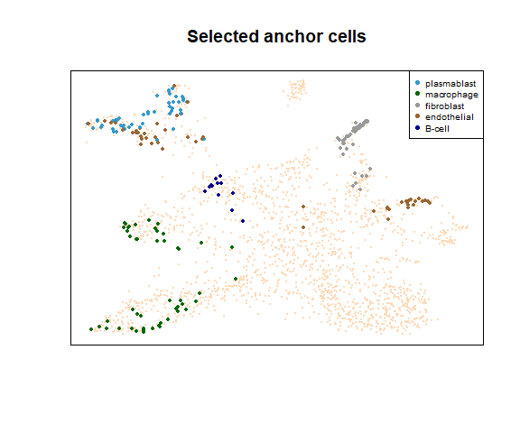

```r
# plot the anchors atop the UMAP:
par(mfrow = c(1,1))
plot(mini_nsclc$umap, pch = 16, cex = 0.1, col = "peachpuff1", xaxt = "n",  yaxt = "n", xlab = "", ylab = "",
     main = "Selected anchor cells")
points(mini_nsclc$umap[!is.na(anchors), ], col = iocolors[anchors[!is.na(anchors)]], pch = 16, cex = 0.6)
legend("topright", pch = 16, col = iocolors[setdiff(unique(anchors), NA)], legend = setdiff(unique(anchors), NA), cex = 0.65)
```

The above example shows a mostly unsuccessful attempt at selecting anchor cells. (The anchor selection code expects a bigger dataset.)

Problems include:

- No anchor cells were found for most immune cell types
- The macrophage anchors (green) occupy two sections of the UMAP - likely one of these sections is a different cell type
- Half the endothelial anchors are mixed with the plasmablast anchors

Countermeaures to these failures could include:

- Use cells’ immunofluorescence values to remove PanCK+ cells from the list of immune cell anchors
- Delete the endothelial anchors that are mixed among the plasmablast anchors

We’ll continue our demonstration of semi-supervised cell typing pretending that the above anchors were satisfactory.

The next step is to use the anchors to update the reference profiles:

```r
updatedprofiles <- updateReferenceProfiles(reference_profiles = ioprofiles,
                                           counts = mini_nsclc$counts,
                                           neg = mini_nsclc$neg,
                                           bg = per.cell.bg,
                                           anchors = anchors)
str(updatedprofiles)
```

```
#> List of 2
#>  $ updated_profiles: num [1:960, 1:5] 0 0 0.019 0 0 0.019 0.039 0 0.019 0.059 ...
#>   ..- attr(*, "dimnames")=List of 2
#>   .. ..$ : chr [1:960] "AATK" "ABL1" "ABL2" "ACE" ...
#>   .. ..$ : chr [1:5] "plasmablast" "macrophage" "fibroblast" "endothelial" ...
#>  $ anchors         : Named chr [1:2198] NA NA NA NA ...
#>   ..- attr(*, "names")= chr [1:2198] "c_3_18_2" "c_3_18_3" "c_3_18_4" "c_3_18_5" ...
```

If we’d been willing to trust the defaults and not examine partial results, we could have skipped the above steps and just run:

```r
updatedprofiles <- updatedprofiles(reference_profiles = ioprofiles,
                                           counts = mini_nsclc$counts,
                                           neg = mini_nsclc$neg,
                                           bg = per.cell.bg,
                                           anchors = NULL)
```

#### Incorporating additional data types

Single-cell spatial transcriptomics datasets offer data types beyond simple gene expression, from single-cell images to spatial contexts. Insitutype digests this information in the form of “cohorts” of cells with similar data from the alternative data types. Then, when assigning cell types, Insitutype will considers the frequency of each cell type in each cohort. For example, if you have a cohort of mainly CD45- cells, Insitutype will see that immune cells are very uncommon within this cohort, and it will give cells in this cohort lower probabilities of falling in immune cell clusters. (Insitutype doesn’t know about CD45 staining; it just considers the frequency of each cluster in each cohort.)

Cohort definition is left to the user, and many approaches are reasonable. For example, you might:

- Define cohort by gating cells’ immunofluorescence stains, e.g. PanCK+/- or CD45+/-
- Cluster cells on their continuous immunofluorescence values
- Use an autoencoder to extract features from cells’ images, then cluster on those features.
- Use the results of spatial clustering / “niches” to define cohorts
- Cluster on information from multiple data types together, such as the average gene expression profile of cell’s neighbors AND immunofluorescence.

Cohorting is a low-risk undertaking, so it is recommended whenever possible. A poorly-defined cohort will simply be uninformative; it will not send the clustering algorithm astray. The more cohorts you can define, and the higher-quality those cohorts, the more information Insitutype will be able to gleam from the alternative data types.

One warning: **do not define cohorts based on variables you want to study.** For example, if you wish to study how cell populations shift across spatial context, then spatial context must not be allowed to inform cell typing. To do so would introduce circularity.

In the below example, we’ll define cohorts using the “fastCohorting” function. This function is provided as a convenient way to derive cohorts from diverse data types; it makes no claim to being optimal.

```r
# simulate immunofluorescence data:
immunofluordata <- matrix(rpois(n = nrow(counts) * 4, lambda = 100),
                          nrow(counts))
# perform automatic cohorting:
cohort <- fastCohorting(immunofluordata,
                        gaussian_transform = TRUE)
# ("Gaussian_transform = TRUE" maps variables to gaussians in order to
#  place dramatically different variables on the same scale.)
table(cohort)
```

```
#> cohort
#>    1    2    3
#> 1236  631  331
```

### Semi-supervised clustering:

The below command performs semi-supervised clustering. We’ll let the algorithm try to select the optimal number of clusters from a range of plausible options using the n_clusts argument.

Note: this should take a few minutes on a standard laptop.

```r
semisup <- insitutype(counts = counts,
                    neg = negmean,
                    cohort = cohort,
                    bg = NULL, # Enter your own per-cell background estimates here if you have them; otherwise insitutype will use the negprobes to estimate background for you.
                    n_clusts = c(5, 6),  # condensed to save time. n_clusts = 5:15 would be more optimal
                    reference_profiles = updatedprofiles$updated_profiles,
                    update_reference_profiles = FALSE,
                    n_phase1 = 200, n_phase2 = 500, n_phase3 = 2000, n_starts = 1, max_iters = 5) # choosing inadvisably low numbers to speed the vignette; using the defaults in recommended.
```

```
#> 6.74 cells per geometric bin.
#> Selecting optimal number of clusters from a range of 5 - 6
#> Clustering with n_clust = 5
#> iter 1
#> iter 2
#> iter 3
#> iter 4
#> iter 5
#> iter 6
#> iter 7
#> iter 8
#> iter 9
#> Converged: <= 0.5% of cell type assignments changed in the last iteration.
#> ==========================================================================
#> Clustering with n_clust = 6
#> iter 1
#> iter 2
#> iter 3
#> iter 4
#> iter 5
#> iter 6
#> iter 7
#> iter 8
#> iter 9
#> Converged: <= 0.5% of cell type assignments changed in the last iteration.
#> ==========================================================================
#> phase 1: random starts in 200 cell subsets
#> iter 1
#> iter 2
#> iter 3
#> iter 4
#> Converged: <= 0.2% of cell type assignments changed in the last iteration.
#> ==========================================================================
#> phase 2: refining best random start in a 500 cell subset
#> iter 1
#> iter 2
#> iter 3
#> iter 4
#> iter 5
#> Converged: <= 0.1% of cell type assignments changed in the last iteration.
#> ==========================================================================
#> phase 3: finalizing clusters in a 2000 cell subset
#> iter 1
#> iter 2
#> iter 3
#> iter 4
#> iter 5
#> phase 4: classifying all 2198 cells
```

The function returns 4 useful outputs: a vector of cells’ cluster assignments, a vector of the posterior probability for each cell typing call, a matrix of cells’ log-likelihoods under each cluster, and a matrix of the mean background-subtracted expression profile of each cluster. A fifth output records log-likelihoods under clusters that ended up with no cells assigned to them.

```r
str(semisup)
```

```
#> List of 5
#>  $ clust                      : Named chr [1:2198] "b" "b" "b" "b" ...
#>   ..- attr(*, "names")= chr [1:2198] "c_3_18_2" "c_3_18_3" "c_3_18_4" "c_3_18_5" ...
#>  $ prob                       : Named num [1:2198] 1 1 1 1 1 ...
#>   ..- attr(*, "names")= chr [1:2198] "c_3_18_2" "c_3_18_3" "c_3_18_4" "c_3_18_5" ...
#>  $ profiles                   : num [1:960, 1:11] 0 0.036 0.0331 0 0 ...
#>   ..- attr(*, "dimnames")=List of 2
#>   .. ..$ : chr [1:960] "AATK" "ABL1" "ABL2" "ACE" ...
#>   .. ..$ : chr [1:11] "a" "b" "c" "d" ...
#>  $ logliks                    : num [1:2198, 1:11] -122 -131 -308 -129 -300 ...
#>   ..- attr(*, "dimnames")=List of 2
#>   .. ..$ : chr [1:2198] "c_3_18_2" "c_3_18_3" "c_3_18_4" "c_3_18_5" ...
#>   .. ..$ : chr [1:11] "a" "b" "c" "d" ...
#>  $ logliks_from_lost_celltypes: num[1:2198, 0 ]
#>   ..- attr(*, "dimnames")=List of 2
#>   .. ..$ : chr [1:2198] "c_3_18_2" "c_3_18_3" "c_3_18_4" "c_3_18_5" ...
#>   .. ..$ : NULL
```

```r
round(head(semisup$prob),2)
```

```
#> c_3_18_2 c_3_18_3 c_3_18_4 c_3_18_5 c_3_18_6 c_3_18_7
#>     1.00     1.00     1.00     1.00     1.00     0.99
```

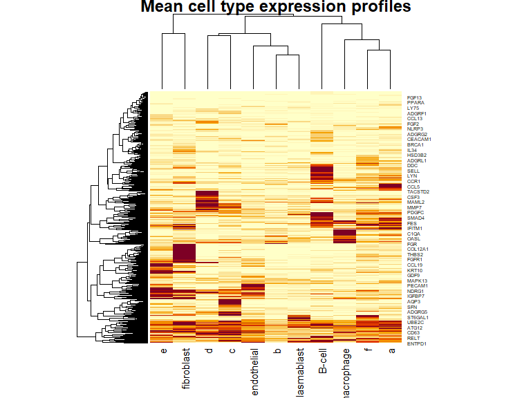

```r
heatmap(sweep(semisup$profiles, 1, pmax(apply(semisup$profiles, 1, max), .2), "/"), scale = "none",
        main = "Mean cell type expression profiles")
```

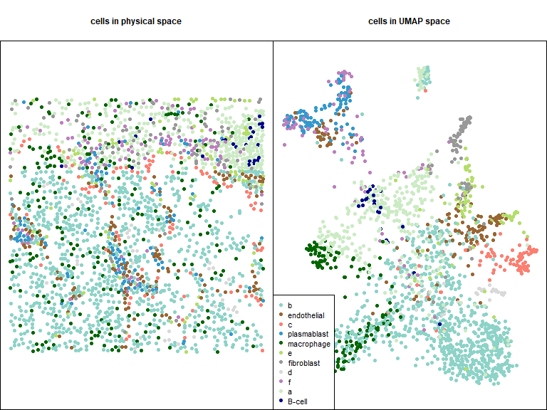

```r
# define cluster colors:
cols <- c('#8DD3C7','#BEBADA','#FB8072','#80B1D3','#FDB462','#B3DE69','#FCCDE5','#D9D9D9','#BC80BD','#CCEBC5','#FFED6F','#E41A1C','#377EB8','#4DAF4A','#984EA3','#FF7F00','#FFFF33','#A65628','#F781BF','#999999')
cols <- cols[seq_along(unique(semisup$clust))]
names(cols) <- unique(semisup$clust)
cols[is.element(names(cols), names(iocolors))] = iocolors[names(cols)[is.element(names(cols), names(iocolors))]]

par(mfrow = c(1,2))
par(mar = c(0,0,3,0))

plot(mini_nsclc$x, mini_nsclc$y, pch = 16, cex = .75, asp = 1, cex.main = 0.75,
          main = "cells in physical space",
     col = cols[semisup$clust], xlab = "", ylab = "", xaxt = "n", yaxt = "n")

plot(mini_nsclc$umap, pch = 16, cex = .75, asp = 1, cex.main = 0.75,
     main = "cells in UMAP space",
     col = cols[semisup$clust], xlab = "", ylab = "", xaxt = "n", yaxt = "n")
legend("bottomleft", pch = 16, col = cols, legend = names(cols), cex = 0.7)
```

### Visualizing clustering results

Insitutype calculates the probability of each cell belonging to each cluster. This information lets us understand how clusters relate to each other. The flightpath_plot function arrays cells according to their cluster probabilities:

```r
# make the flightpath plot
fp <- flightpath_plot(flightpath_result = NULL, insitutype_result = semisup, col = cols[semisup$clust])
class(fp)
```

```
#> [1] "gg"     "ggplot"
```

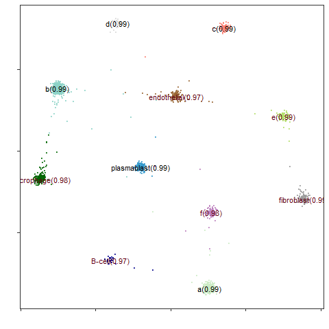

```r
print(fp)
```

In the above plot, a cell atop a cluster centroid is near-certain, while cells halfway between two centroids have 50% posterior probability of belonging to each of those two clusters. The number by each centroid gives the average posterior probability of cells in the cluster. Expect to see this value above 0.9 for clustering major cell types, and above 0.75 when clustering apart closely-related cell types. Clusters with average posterior probabilities are unreliable. You can either interpret them with caution, or you can dissolve them and reassign their cells to other clusters. (The next section covers this operation.)

You can also extract the flightpath layout for plotting on your own:

```r
# compute the flightpath layout:
fp_layout <- flightpath_layout(logliks = semisup$logliks, profiles = semisup$profiles)
str(fp_layout)
```

```
#> List of 4
#>  $ clustpos      : num [1:11, 1:2] -7.26 -2.39 6.4 1.85 7.24 ...
#>   ..- attr(*, "dimnames")=List of 2
#>   .. ..$ : chr [1:11] "a" "b" "c" "d" ...
#>   .. ..$ : chr [1:2] "x" "y"
#>  $ cellpos       : num [1:2198, 1:2] -2.17 -2.54 -2.22 -2.5 2.68 ...
#>   ..- attr(*, "dimnames")=List of 2
#>   .. ..$ : chr [1:2198] "c_3_18_2" "c_3_18_3" "c_3_18_4" "c_3_18_5" ...
#>   .. ..$ : chr [1:2] "x" "y"
#>  $ clust         : chr [1:2198] "b" "b" "b" "b" ...
#>  $ meanconfidence: Named num [1:11] 0.994 0.993 0.994 0.992 0.987 ...
#>   ..- attr(*, "names")= chr [1:11] "a" "b" "c" "d" ...
```

```r
# plot it:
#par(mar = c(0,0,0,0))
#plot(fp_layout$cellpos, pch = 16, cex = 0.5, col = cols[semisup$clust], xaxt = "n", yaxt = "n", xlab = "", ylab = "")
#text(fp_layout$clustpos, rownames(fp_layout$clustpos), cex = 0.5)
```

#### Updating clustering results

After close review, you might want to update your clustering results.

The function refineClusters can modify your results in the following ways:

- merge closely-related or frequently-confused clusters
- delete clusters (Sometimes a “catch-all” cluster arises that is frequently confused wiht multiple other clusters. It’s best to delete these clusters and let their cells get reassigned to meaningful clusters.)
- sub-cluster large clusters

```r
# refine the clusters:
newclusts <- refineClusters(logliks = semisup$logliks,
                            merges = c("fibroblast" = "stroma", "endothelial" = "stroma"),
                            to_delete = c("a"),
                            subcluster = NULL, # subclustering via refineClusters is not recommended for semi-supervised results
                            counts = counts,
                            neg = negmean)
str(newclusts)
```

```
#> List of 5
#>  $ clust                      : Named chr [1:2198] "b" "b" "b" "b" ...
#>   ..- attr(*, "names")= chr [1:2198] "c_3_18_2" "c_3_18_3" "c_3_18_4" "c_3_18_5" ...
#>  $ prob                       : Named num [1:2198] 1 1 1 1 1 ...
#>   ..- attr(*, "names")= chr [1:2198] "c_3_18_2" "c_3_18_3" "c_3_18_4" "c_3_18_5" ...
#>  $ logliks                    : num [1:2198, 1:9] -122 -141 -330 -143 -266 ...
#>   ..- attr(*, "dimnames")=List of 2
#>   .. ..$ : chr [1:2198] "c_3_18_2" "c_3_18_3" "c_3_18_4" "c_3_18_5" ...
#>   .. ..$ : chr [1:9] "stroma" "b" "c" "d" ...
#>  $ profiles                   : num [1:960, 1:9] 0 0.0112 0.1279 0.0196 0.0154 ...
#>   ..- attr(*, "dimnames")=List of 2
#>   .. ..$ : chr [1:960] "AATK" "ABL1" "ABL2" "ACE" ...
#>   .. ..$ : chr [1:9] "stroma" "b" "c" "d" ...
#>  $ logliks_from_lost_celltypes: num[1:2198, 0 ]
#>   ..- attr(*, "dimnames")=List of 2
#>   .. ..$ : chr [1:2198] "c_3_18_2" "c_3_18_3" "c_3_18_4" "c_3_18_5" ...
#>   .. ..$ : NULL
```

```r
# plot the updated results:
cols["stroma"] = "black"
fp <- flightpath_plot(flightpath_result = NULL, insitutype_result = newclusts, col = cols[newclusts$clust])
class(fp)
```

```
#> [1] "gg"     "ggplot"
```

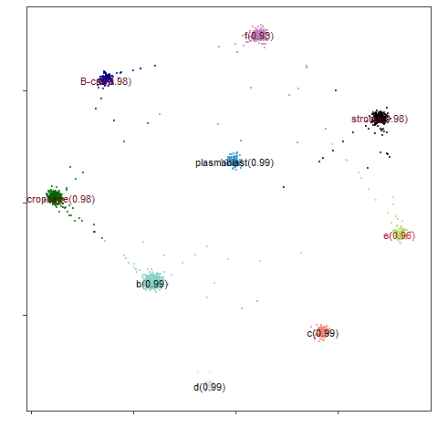

```r
print(fp)
```

### Coloring cell types

The colorCellTypes function attempts to choose good colors for your cell types. Some of its options use the frequency of cell types in this decision. Here are 3 versions:

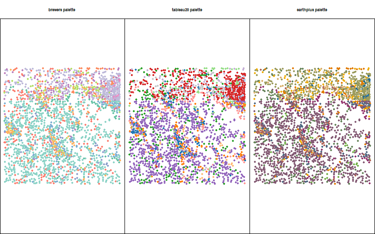

```r
par(mfrow = c(1,3))
par(mar = c(0,0,3,0))

plot(mini_nsclc$x, mini_nsclc$y, pch = 16, cex = .75, asp = 1, cex.main = 0.75,
          main = "brewers palette",
     col = colorCellTypes(freqs = table(semisup$clust), palette = "brewers")[semisup$clust],
     xlab = "", ylab = "", xaxt = "n", yaxt = "n")

plot(mini_nsclc$x, mini_nsclc$y, pch = 16, cex = .75, asp = 1, cex.main = 0.75,
          main = "tableau20 palette",
     col = colorCellTypes(freqs = table(semisup$clust), palette = "tableau20")[semisup$clust],
     xlab = "", ylab = "", xaxt = "n", yaxt = "n")

plot(mini_nsclc$x, mini_nsclc$y, pch = 16, cex = .75, asp = 1, cex.main = 0.75,
          main = "earthplus palette",
     col = colorCellTypes(freqs = table(semisup$clust), palette = "earthplus")[semisup$clust],
     xlab = "", ylab = "", xaxt = "n", yaxt = "n")
```